# Regression

Anna Yeaton

Fall 2019

# Lab Section

In this lab, we will go over regression. We will be using the caret package in R. https://topepo.github.io/caret/train-models-by-tag.html

# Perfomance Metrics

## Residual

Deviation of the observed value to the estimated value (sample mean)
$$residual=y_i - \hat{y_i}$$
where $\hat{y_i}$ is the estimated value

## Mean Squared Error (MSE)

$$MSE=\frac{1}{n}\sum_{i=1}^{n}(y_i - \hat{y_i})^2$$

## Root Mean Squared Error (RMSE)

Same units as original data.

$$RMSE=\sqrt{MSE}$$

## L2 regularization : Ridge regression. Regularize by adding the sum of the coefficients, squared, to the function.

$$Ridge Regression=\sum_{i=1}^{n}(y_i - w_0 - \sum_{j=1}^{p}w_jx_{ij})^2 + \lambda\sum_{j=1}^p(w_j)^2$$

## L1 regularization : Lasso Regression. Regularize by adding the sum of the absolute value of the coefficients to the model. Coefficient estimates may be pushed to zero – Lasso can perform variable selection

$$Lasso Regression=\sum_{i=1}^{n}(y_i - w_0 - \sum_{j=1}^{p}w_jx_{ij})^2 + \lambda\sum_{j=1}^p|w_j|$$

### The broad steps of Machine learning in R.

1. Split the data into training and test. Set test aside.
2. Fit a good model to the training data.
3. See how your model did on the training data.
4. Test how your model performs on the test data.

# Regression

1. Split data into training and test set (75% in train set, 25% in test set)

```r
dt = sort(sample(nrow(airquality), nrow(airquality)*.75))
train_regression = airquality[dt,]
test_regression = airquality[-dt,]
#train_regression
```

### Linear Regression

- Assumes a linear relationship.
- Independent variables should not be correlated (no mulitcollinearity)
- The number of observations should be greater than the number of independent variables.

$$RSS=\sum(y_i - \hat{y_i})^2$$
We will predict the response of the Temperature based on Wind.

This is the data we will fit a linear model to.

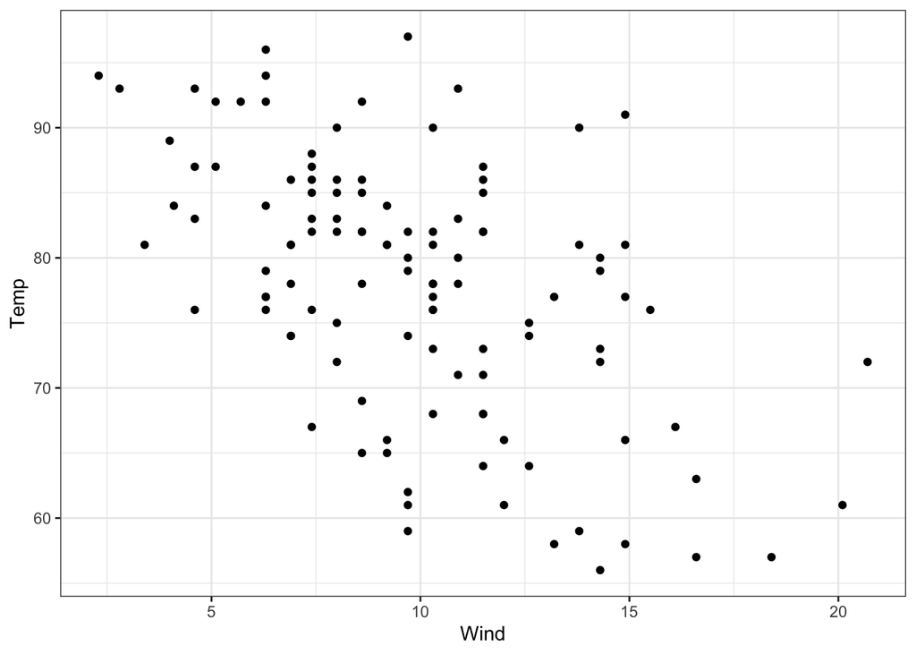

```r
 ggplot(data = train_regression) +
   geom_point(aes(x=Wind, y=Temp)) +
   theme_bw()
```

2. Create and fit a linear model to predict Temperature from Wind using the training set

```r
#help(train)
lin_co <-
linear_regression <- train(Temp ~ Wind, data= train_regression , method = "lm")
```

3. Vizualize how your model performed on the train data by plotting the regression line on top of the train data points.

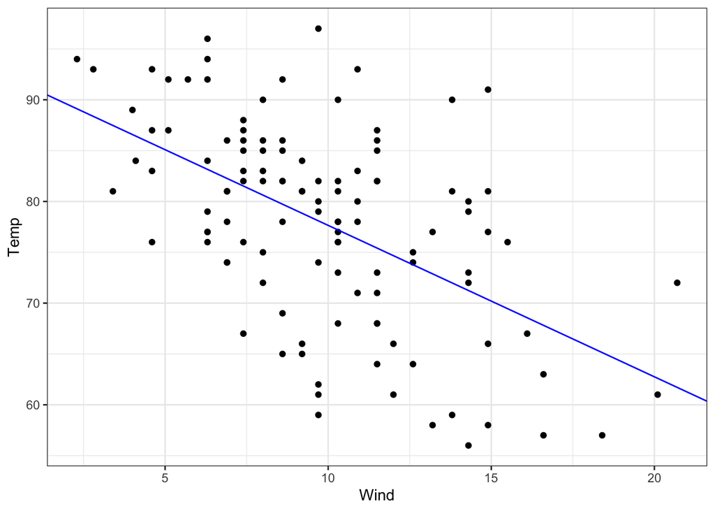

```r
lin_co <- linear_regression$finalModel$coefficients
ggplot(data = train_regression) +
   geom_point(aes(x=Wind, y=Temp)) +
   geom_abline(aes(intercept = lin_co[1], slope = lin_co[2]), col = "blue")+
   theme_bw()
```

4. Explore how the model performs on the test data. For Linear Regression:
- The residuals should be close to zero.
- There should be equal variance around the regression line (homoscedasticity).
- Residuals should be normally distributed.
- Independent variables and residuals should not be correlated.

4 a) See how the model performs on the test data

```r
#help(predict)
linear_predict <- predict(linear_regression, test_regression)
linear_predict
```

```
##        4       12       14       22       27       28       30       39
## 75.41324 78.09406 76.30685 67.81758 80.62595 74.66857 84.05144 82.26423
##       43       44       45       46       53       57       59       60
## 78.83874 80.62595 71.98775 75.41324 90.00883 80.62595 75.41324 70.34947
##       63       65       68       71       74       83       88      103
## 78.83874 76.30685 84.94505 81.51956 70.34947 78.09406 74.66857 75.41324
##      107      110      113      119      124      129      132      133
## 75.41324 81.51956 69.45586 84.05144 82.26423 69.45586 76.30685 78.09406
##      134      140      145      147      149      151      152
## 70.34947 71.98775 78.83874 77.20046 82.26423 71.24307 80.62595
```

4 b) Look at the residuals. Are they close to zero?

```r
#look at the median residual value. Close to zero is best
#help(summary)
summary(linear_regression)
```

```
##
## Call:
## lm(formula = .outcome ~ ., data = dat)
##
## Residuals:
##     Min      1Q  Median      3Q     Max
## -19.094  -6.025   1.065   5.454  20.651
##
## Coefficients:
##             Estimate Std. Error t value Pr(>|t|)
## (Intercept)  92.5407     2.3164  39.950  < 2e-16 ***
## Wind         -1.4893     0.2212  -6.732 7.47e-10 ***
## ---
## Signif. codes:  0 '***' 0.001 '**' 0.01 '*' 0.05 '.' 0.1 ' ' 1
##
## Residual standard error: 8.419 on 112 degrees of freedom
## Multiple R-squared:  0.2881, Adjusted R-squared:  0.2817
## F-statistic: 45.32 on 1 and 112 DF,  p-value: 7.47e-10
```

4 c) Plot predicted temperature vs observed temperature. A strong model should show a strong correlation

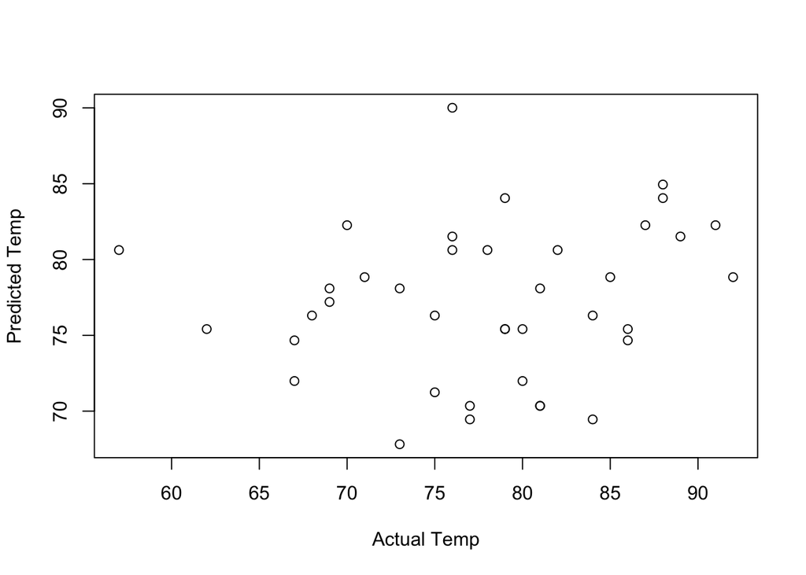

```r
actual_pred <- data.frame(cbind(actual=test_regression$Temp, predicted=linear_predict))
correlation_accuracy <- cor(actual_pred)

plot(actual_pred$actual, actual_pred$predicted, xlab = "Actual Temp", ylab = "Predicted Temp")
```

4 d) Visualize the predicted values in relation to the real data points. Look for homoscedasticity

```r
# Extract coefficients from the model
lin_co <- linear_regression$finalModel$coefficients
lin_co
```

```
## (Intercept)        Wind
##   92.540713   -1.489345
```

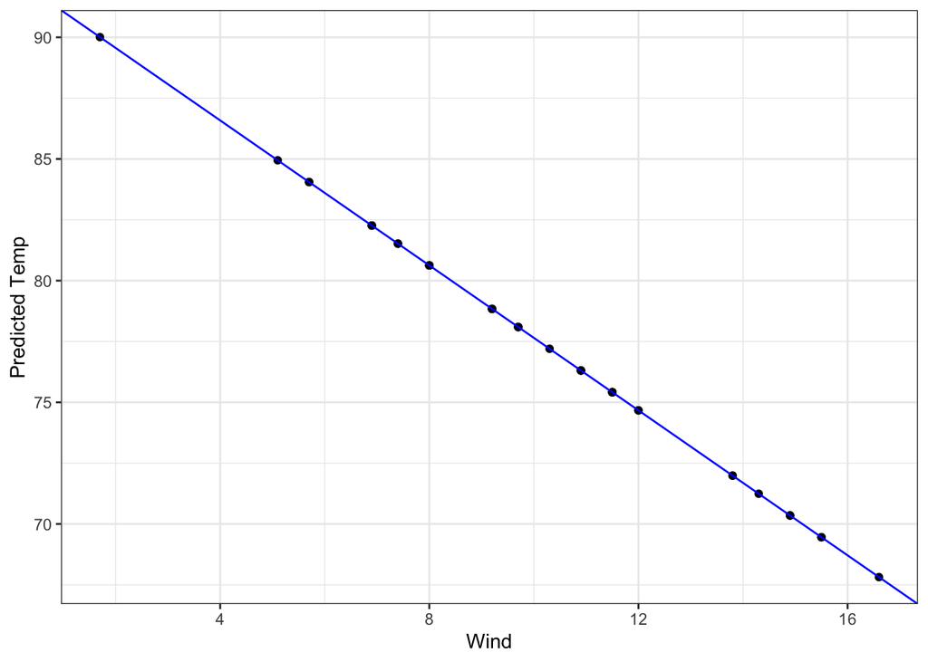

```r
# plot the regression line on the predicted values
ggplot(data = test_regression) +
   geom_point(aes(x=Wind, y=actual_pred$predicted)) +
   geom_abline(aes(intercept = lin_co[1], slope = lin_co[2]), col = "blue")+
   theme_bw()+ ylab("Predicted Temp")
```

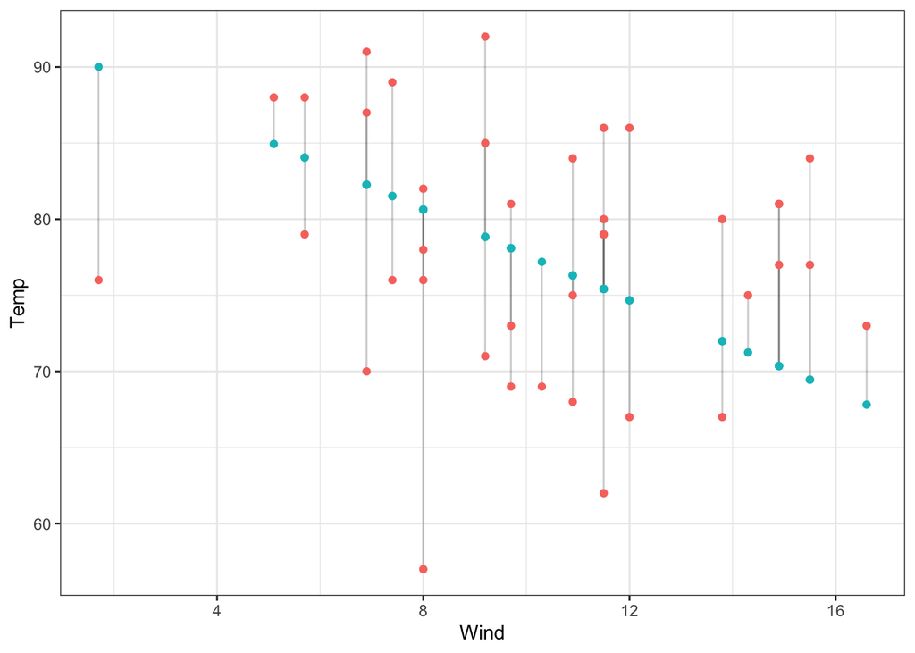

```r
# plot the original test values
ggplot(data = test_regression, aes(x = Wind, y = Temp)) +
  geom_segment(aes(xend = Wind, yend = actual_pred$predicted), alpha = .2) +
  geom_point(aes(color = "blue")) +
  guides(color = FALSE, size = FALSE) +
  geom_point(aes(y = actual_pred$predicted, col = "red")) +
  theme_bw()
```

4 e) Residuals should be normally distributed. Plot the density of the residuals

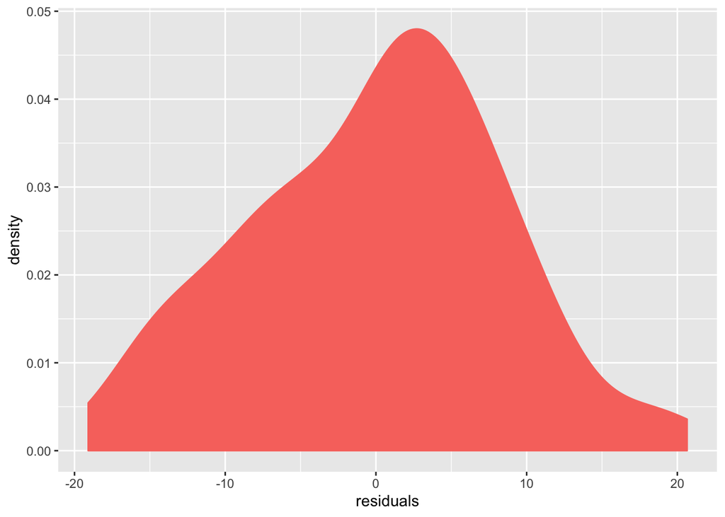

```r
residuals_lin <- residuals(linear_regression)

ggplot() + geom_density(aes(residuals_lin, col = "red", fill = "red"), show.legend = FALSE) + xlab('residuals')
```

4 f) Independent variables and residuals should not be correlated

```r
cor.test(train_regression$Wind, resid(linear_regression))
```

```
##
##  Pearson's product-moment correlation
##
## data:  train_regression$Wind and resid(linear_regression)
## t = -3.2013e-16, df = 112, p-value = 1
## alternative hypothesis: true correlation is not equal to 0
## 95 percent confidence interval:
##  -0.1839148  0.1839148
## sample estimates:
##           cor
## -3.024916e-17
```

### Linear Regression with Regularization

5. Create a linear model using L1 or L2 regularization to predict Temperature from Wind and Month variables. Plot your predicted values and the real Y values on the same plot.

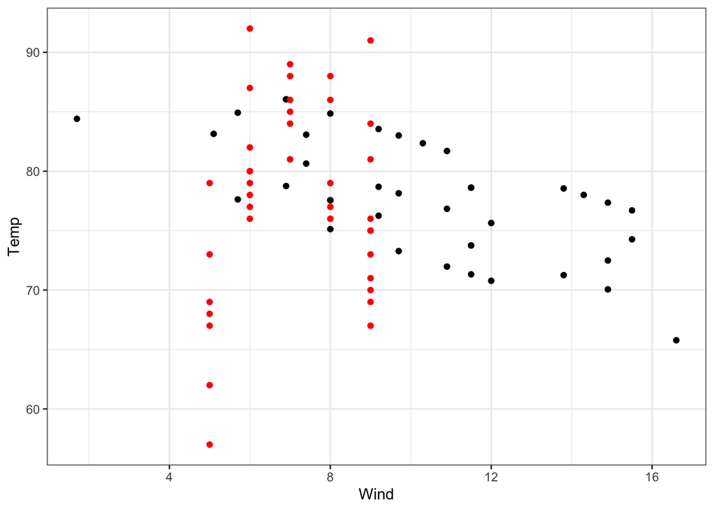

```r
lasso_reg <- train(Temp ~ Wind + Month, data = train_regression, method = "lasso")
lass_predict <- predict(lasso_reg, test_regression)
a_p <- data.frame(cbind(actual=test_regression$Temp, predicted=lass_predict))

ggplot(data = test_regression) +
   geom_point(aes(x=Wind, y=a_p$predicted)) +
   geom_point(aes(x=Month, y=a_p$actual), col = "red") +
   theme_bw()+ ylab("Temp")
```

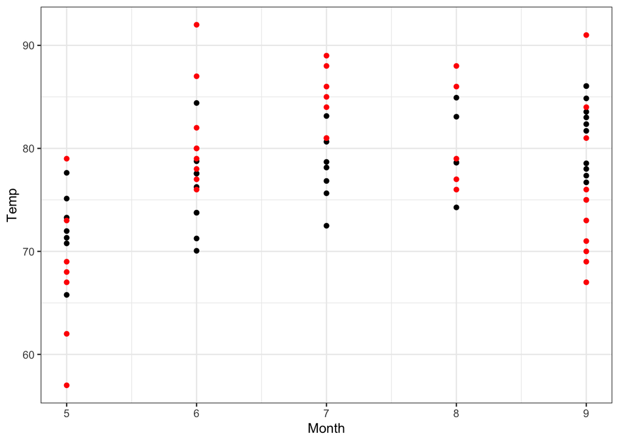

```r
ggplot(data = test_regression) +
   geom_point(aes(x=Month, y=a_p$predicted)) +
   geom_point(aes(x=Month, y=a_p$actual), col = "red") +
   theme_bw()+ ylab("Temp")
```